# Weaning

First-exploration report

Corrado Lanera https://CorradoLanera.it (Unit of Biostatistics, Epidemiology, and Public Health)https://www.unipd-ubep.it/ , Silvano Salaris (Unit of Biostatistics, Epidemiology, and Public Health)https://www.unipd-ubep.it/ , Giulia Lorenzoni (Unit of Biostatistics, Epidemiology, and Public Health)https://www.unipd-ubep.it/ , Danila Azzolina (Unit of Biostatistics, Epidemiology, and Public Health)https://www.unipd-ubep.it/ , Dario Gregori (Unit of Biostatistics, Epidemiology, and Public Health)https://www.unipd-ubep.it/  
2023-02-02

[figure not shown]

## Introduction

Weanings data are stored in two main types of files:

Data types are three: there are REG files also. See section **Discussion** for more details.

- TRD, reporting ventilators signals averaged every minute.
- LOG, reporting alarms and additional information from the ventilators

TRD and LOG files are collected in pairs, reporting data from approximately 24 hours each pair. So, every patient have multiple pairs of TRD and LOG files. Pairs from all the patient of a center involved in the study are collected in a folder named with the center code. An additional **mother** folder contains all the center’s folders.

## Methods

The pipeline developed is currently in the following state

The pipeline itself, derived objects, and the report are automatically monitored for outdated nodes, and updated at any change in the code or data.

[interactive chart not shown]

## Results

### TRD

- The merged TRD dataset has 2126177 rows, and 38 columns.

Here below a sample of 50 (random) records.

|  | folder | file | id_pat | date | ora | et_co2_percent | eliminazione_co2_corrente_ml | eliminazione_co2_minuto_ml_min | caratteristiche_dinamiche_ml_cm_h2o | elastanza_cm_h2o_l | flusso_di_fine_esp_l_min | pressione_di_fine_esp_cm_h2o | resistenza_esp_cm_h2o_l_s | vol_minuto_espirato_l_min | vol_corrente_espirato_ml | concentraz_o2_percent | resistenza_inspiratoria_cm_h2o_l_s | vol_minuto_inspirato_l_min | vol_corrente_inspirato_ml | press_media_vie_aeree_cm_h2o | frequenza_respiraz_misurata_resp_min | freq_spontanea_resp_min | picco_edi_m_v | edi_min_m_v | press_di_pausa_vie_aeree_cm_h2o | press_di_picco_delle_vie_aeree_cm_h2o | passa_a_backup_min | backup_percent_min | compliance_statica_ml_cm_h2o | … |
| --- | --- | --- | --- | --- | --- | --- | --- | --- | --- | --- | --- | --- | --- | --- | --- | --- | --- | --- | --- | --- | --- | --- | --- | --- | --- | --- | --- | --- | --- | --- |
| 1 | BS | BS022_1409 | 22 | 2014-06-12 | 11:49:00 |  |  |  | 85.79 |  | 0.444 | 4.92 |  | 6.0607 | 268 | 49.5 |  | 9.7806 | 403.8 | 6.17 | 22.89 | 22.89 |  |  |  | 8.1 | 0 | 0 |  | … |
| 2 | BS | BS009_995 | 9 | 2014-02-14 | 22:06:00 |  |  |  | 19.74 |  | 0.726 | 4.83 |  | 6.1272 | 187.5 | 32.6 |  | 9.4437 | 287.3 | 8.44 | 32.66 | 32.66 | 8.96 | 1.16 |  | 14.28 |  |  |  | … |
| 3 | FE | FE026_1583 | 26 | 2014-09-11 | 17:42:00 |  |  |  | 53.39 |  | 0.846 | 5.58 |  | 9.7697 | 396.5 | 30.8 |  | 9.8017 | 469.5 | 7.71 | 22.58 | 22.58 |  |  |  | 13.3 | 0 | 0 |  | … |
| 4 | CM | CM010_971 | 10 | 2014-02-11 | 08:51:00 |  |  |  | 27.76 |  | 0.03 | 4.73 |  | 8.6312 | 505.9 | 59.2 |  | 8.6484 | 509.3 | 13.01 | 17.05 | 17.05 |  |  |  | 22.91 |  |  |  | … |
| 5 | BA | BA006_1740 | 6 |  | 23:19:00 |  |  |  | 66.92 |  | 0.516 | 7.66 |  | 6.3316 | 306.6 | 70.9 |  | 6.3498 | 346.6 | 9.07 | 18.5 | 18.5 | 5.52 | 0.19 |  | 13.63 | 0 | 0 |  | … |
| 6 | NO | NO002_156 | 2 | 2013-08-26 | 07:22:00 |  |  |  | 55.44 |  | 0.222 | 6.71 |  | 6.792 | 256.8 | 25.5 |  | 7.0564 | 328.5 | 8.27 | 23.69 | 23.69 | 2.75 | 0.55 |  | 11.72 | 0 | 0 |  | … |
| 7 | CM | CM017_1516 | 17 | 2014-07-28 | 13:38:00 |  |  |  | 33.73 |  | 0.78 | 2.31 |  | 8.6061 | 658.6 | 61.4 |  | 8.4752 | 646.6 | 6.07 | 12.78 | 12.78 |  |  |  | 21.87 | 0 | 0 |  | … |
| 8 | LG | LG021_1262 | 21 | 2014-05-04 | 20:49:00 |  |  |  | 48.54 |  | 2.76 | 7.63 |  | 13.6702 | 472.7 | 38 |  | 13.7966 | 528.8 | 9.86 | 28.31 | 28.3 | 5.65 | 0.26 |  | 18.8 | 0 | 0 |  | … |
| 9 | BG | BG002_270 | 2 | 2013-09-27 | 14:04:00 |  |  |  | 41.39 |  | 0.18 | 7.27 |  | 10.8088 | 398.8 | 44.1 |  | 10.6373 | 406.6 | 10.59 | 26.14 | 26.14 | 7 | 0.29 |  | 16.91 | 0 | 0 |  | … |
| 10 | TS | TS014_1543 | 14 |  | 12:51:00 |  |  |  |  |  |  |  |  |  |  |  |  |  |  |  |  |  | 19.56 | 0.26 |  |  |  |  |  | … |

[output cut: 40 more lines]

### LOG

- The merged LOG dataset has 441704 rows, and 11 columns.

Here below a sample of 50 (random) records.

|  | folder | file | id_pat | data | ora | id_info | tipo | informazioni | time | id_univoco | date |
| --- | --- | --- | --- | --- | --- | --- | --- | --- | --- | --- | --- |
| 1 | FE | FE027_1634 | 27 | 2014-09-18 | 23:36:09 | 277 | Variaz. parametro | I:E di backup impostato a 1:2.0 | 2014-09-18T23:36:09Z | FE027 | 2014-09-18 |
| 2 | NO | NO010_1268 | 10 | 2014-05-06 | 17:46:42 | 274 | Variaz. parametro | Frequenza resp. impostata a 15 resp/min | 2014-05-06T17:46:42Z | NO010 | 2014-05-06 |
| 3 | BS | BS012_774 | 12 | 2014-01-01 | 10:33:43 | 339 | Variaz. parametro | Possibilità di impostare profili di flusso alternativi in VC Disabilitata | 2014-01-01T10:33:43Z | BS012 | 2014-01-01 |
| 4 | LG | LG007_275 | 7 | 2013-10-05 | 07:49:48 | 125 | Allarme | Allarme: PEEP bassa | 2013-10-05T07:49:48Z | LG007 | 2013-10-05 |
| 5 | FE | FE003_17 | 3 | 2013-07-12 | 06:29:42 | 63 | Allarme | Allarme: Vol. Corrente Insp. fuori range | 2013-07-12T06:29:42Z | FE003 | 2013-07-12 |
| 6 | BS | BS009_766 | 9 | 2014-01-05 | 16:34:53 | 277 | Variaz. parametro | I:E di backup impostato a 1:2.0 | 2014-01-05T16:34:53Z | BS009 | 2014-01-05 |
| 7 | CM | CM006_570 | 6 | 2013-11-28 | 10:01:10 | 267 | Variaz. parametro | Pressione sopra PEEP impostata a 9 cmH₂O | 2013-11-28T10:01:10Z | CM006 | 2013-11-28 |
| 8 | AN | AN008_1912 | 8 | 2014-12-16 | 21:09:31 | 291 | Variaz. parametro | Concentrazione O₂ impostata a 80 % | 2014-12-16T21:09:31Z | AN008 | 2014-12-16 |
| 9 | CM | CM019_1592 | 19 | 2014-09-14 | 16:04:14 | 62 | Allarme | Allarme: Frequenza respiratoria bassa | 2014-09-14T16:04:14Z | CM019 | 2014-09-14 |
| 10 | TS | TS013_1142 | 13 | 2014-03-23 | 08:35:12 | 12 | Allarme | Allarme: Press. vie aeree elevata | 2014-03-23T08:35:12Z | TS013 | 2014-03-23 |

[output cut: 40 more lines]

## Preliminar analyses

### Descriptives

|  | Centro | Numero pazienti |
| --- | --- | --- |
| 1 | FE | 27 |
| 2 | LG | 27 |
| 3 | BS | 25 |
| 4 | CM | 24 |
| 5 | NO | 23 |
| 6 | TS | 15 |
| 7 | VC | 15 |
| 8 | VM | 11 |
| 9 | AN | 10 |
| 10 | BA | 9 |

[output cut: 4 more lines]

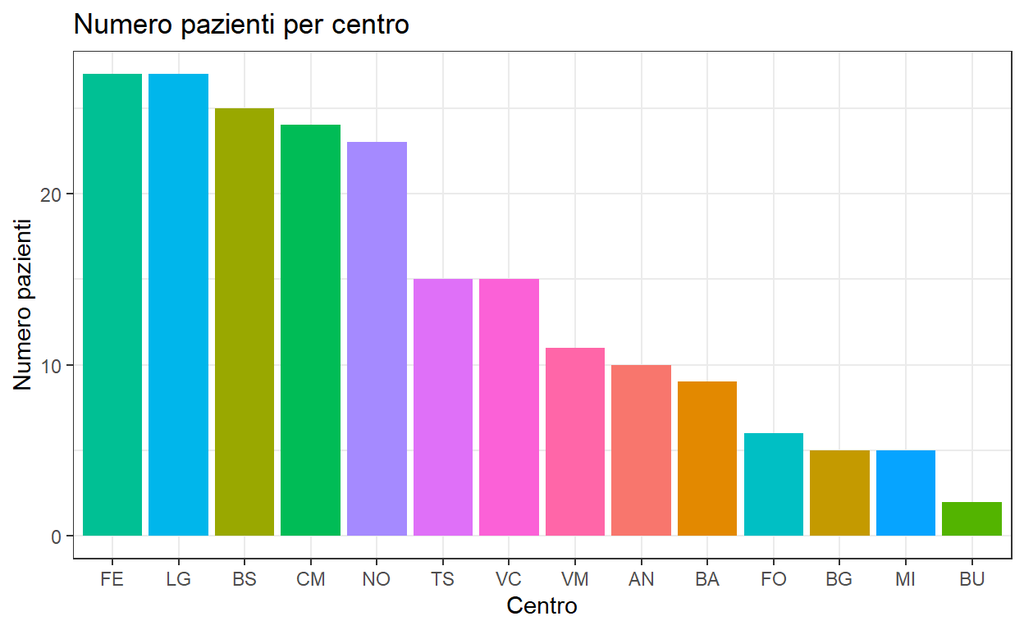

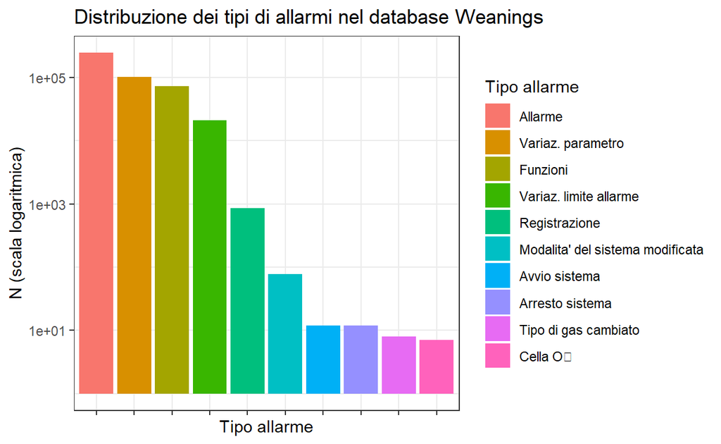

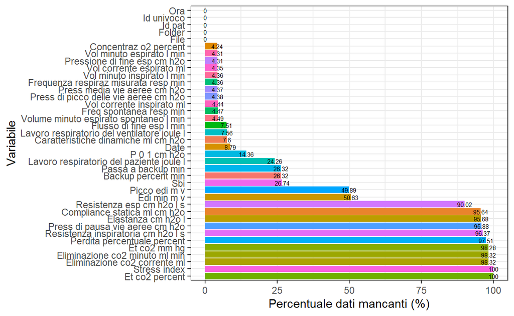

## Discussion

### Issues

- some lines of signals have wrong time and they results in duplicated records. This issue involves the following records

|  | file | id_pat | date | ora | dupe_count | folder | et_co2_percent | eliminazione_co2_corrente_ml | eliminazione_co2_minuto_ml_min | caratteristiche_dinamiche_ml_cm_h2o | elastanza_cm_h2o_l | flusso_di_fine_esp_l_min | pressione_di_fine_esp_cm_h2o | resistenza_esp_cm_h2o_l_s | vol_minuto_espirato_l_min | vol_corrente_espirato_ml | concentraz_o2_percent | resistenza_inspiratoria_cm_h2o_l_s | vol_minuto_inspirato_l_min | vol_corrente_inspirato_ml | press_media_vie_aeree_cm_h2o | frequenza_respiraz_misurata_resp_min | freq_spontanea_resp_min | picco_edi_m_v | edi_min_m_v | press_di_pausa_vie_aeree_cm_h2o | press_di_picco_delle_vie_aeree_cm_h2o | passa_a_backup_min | backup_percent_min | … |
| --- | --- | --- | --- | --- | --- | --- | --- | --- | --- | --- | --- | --- | --- | --- | --- | --- | --- | --- | --- | --- | --- | --- | --- | --- | --- | --- | --- | --- | --- | --- |
| 1 | CM021_1644 | 21 | 2014-09-20 | 07:35:00 | 2 | CM |  |  |  |  |  |  | 4.96 |  | 8.4908 | 541.2 | 62.3 |  | 8.5131 | 548.9 | 9.64 | 15.65 | 0 |  |  |  | 15.8 |  |  | … |
| 2 | CM021_1644 | 21 | 2014-09-20 | 07:35:00 | 2 | CM |  |  |  |  |  |  | 5.12 |  | 6.7173 | 441.3 | 45.6 |  | 6.7049 | 444.6 | 9.91 | 15.15 | 0.18 |  |  |  | 15.4 |  |  | … |
| 3 | LG014_919 | 14 | 2014-02-02 | 17:04:00 | 2 | LG |  |  |  | 50.6 |  | 0 | 14.43 |  | 6.5367 | 347.3 | 49.3 |  | 6.7455 | 346.2 | 16.22 | 19.36 | 19.35 | 2.69 | 0.14 |  | 21 | 0 | 0 | … |
| 4 | LG014_919 | 14 | 2014-02-02 | 17:04:00 | 2 | LG |  |  |  | 40.48 |  | 1.752 | 14.62 |  | 8.0936 | 511.5 | 49 |  | 8.5979 | 521.4 | 17.65 | 24.53 | 24.53 | 1.54 | 0.42 |  | 30.54 | 0 | 0 | … |

- File in the `VC/` folder are the only one using ISO format for dates. We have managed that correctly to consistently merge them with the other files.
- In alcuni file LOG (es: `AN004_869`) il nome del paziente non è riportato come codifica ma esplicitamente. Gli id dei pazienti sono stata importanti sempre recuperandoli dal nome del file.

Nell’intestazione dei file compare sia “nome paziente” che “id paziente”, il primo ogni tanto ha il nome esplicito ogni tanto l’id. A volte uno dei due manca.

### Questions

- There are **REG** files inside the folders which are not reported as used in the thesis or in the Python importing script. Do they need to be used? (How?) They seams to have live data (without explicit time) of the following form:

```
Fase respiro    Pressione   Flusso  Volume          Trigger
Fase    cmH₂O   l/min   ml
```

## Acknowledgments

For the Weaning project, we have setup an automated environment tracking changes and updates within the defined pipeline (from import, preprocess, analyses, and reporting) (Landau 2023).

Data are imported using functions from the `{tidyverse}` suite of R packages mainly (Wickham 2022).

## Environment

Landau, William Michael. 2023. *Targets: Dynamic Function-Oriented Make-Like Declarative Pipelines*.

Wickham, Hadley. 2022. *Tidyverse: Easily Install and Load the Tidyverse*.